# Houston’s Dead Hand Wasn’t *That* Unlikely

Michael O’Dell

5/30/2018

The Rockets had great first half and a bad second half of the Western Conference Finals game 7 against the Golden State Warriors. But was it a meltdown for the ages? A lottery jackpot of bad luck? Many have focused on the 27-in-a-row missed 3-pointers. FiveThirtyEight highlights the odds of Houston’s game 7 cold streak at [1 in 72,000](https://fivethirtyeight.com/features/the-odds-of-the-rockets-missing-that-many-3s-1-in-72000/). The Ringer says the odds were [1 in 186,220](https://www.theringer.com/nba/2018/5/29/17404748/houston-rockets-27-straight-misses-game-7-warriors). Really? A 1-in-a-couple-millennia bad game? Hardly.

### Ignore ‘the Streak’

It’s not how many misses in a row that made the difference in game 7, it’s that the Rockets only made seven 3-pointers the entire game (tied for the fewest they made all season). Any number of those seven shots from distance could have come in during Curry’s 3-pointer 4-for-5 third quarter onslaught, and then people would have been talking about a 20-in-a-row (1 in 7,522 chance), a 14-in-a-row (1 in 516), or a pick-your-favorite-number-in-a-row miss streak. But whatever the number, it wasn’t the streak per se that caused Houston to lose.

What did cause the Rockets to lose game 7 was their overall 15.9% 3-point shooting percentage Monday night. That was certainly Houston’s worst 3-point shooting percentage of the season, but how unlikely was such a poor showing? Houston played 99 games this season (regular + playoffs). That history can give us a pretty good answer along with an answer to another burning question, “would Chris Paul have made a difference?”

### Lightning strikes … *twice?*

99 games is not a huge data set for a continous variable with a potentially high variance (such as 3-point shooting percentage). As a result, the density plot shows that Houston’s actual per game 3-point shooting percentage is not exactly normal, but it’s pretty close.

Using a normal distribution approximation for our analysis makes it possible to calculate the probability (and the odds) of any given range of 3-point shooting percentage (e.g., the probability of Houston shooting 15.9% or worse from downtown).

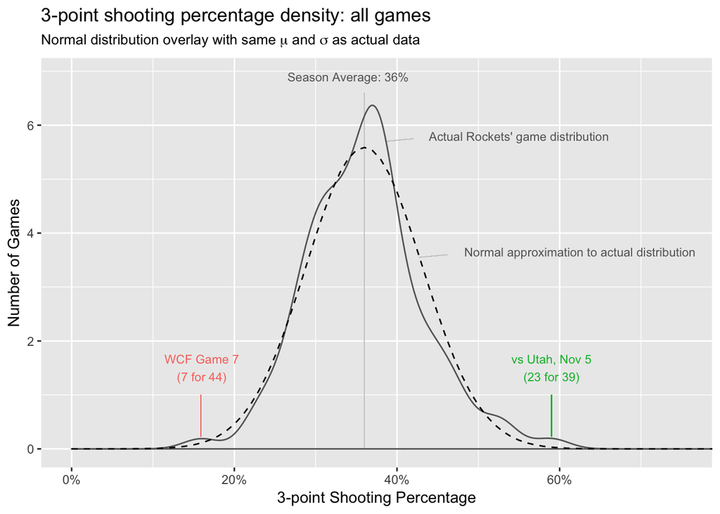

A couple things to notice on the plot:

1. Game 7 is way out on the left edge of the distribution - so it certainly won’t be very probable.
2. There are also several good (3 of them) way out on the right edge of the distribution!

Houston’s three best games in terms of 3-point shooting percentage were a regular season game against Portland on March 20 (.528), a playoff game April 29th against Utah (.531), and a lights-out game November 5th against Utah where the Rockets shot .590.

Houston’s average 3-point shooting percentage on the season was.360. In the November game against Utah, the Rockets shot 23 percentage points more than their season average (or 3.2 standard deviations away from the mean). In game 7 Houston shot 20 percentage points less than their season average (2.8 standard deviations away from the mean). *Their game 7 three-point shooting percentage wasn’t even their most unlikely game! Their November game was!*

SSo how unlikely were these two games? Not very. Based on this distribution, we could expect to see a 3-point shooting game as bad (or worse) from Houston about once every 486 games. Assuming a deep run into the playoffs every year, that’s once every five seasons or so. Even more unlikely is the Rockets 23 on 39 night. We could expect to see Houston shoot that well (or better) once every 1260 games! So don’t hold your breath waiting for another like that.

But to have two such unlikely games should make us question our model. Two lightning strikes in one seasons is unlikely (over 611,000-to-1 in this case). And while [stranger things](https://en.wikipedia.org/wiki/Roy_Sullivan) have happened, we may do well to examine the data more closely.

### But what about Chris Paul?

Answering the question “would Chris Paul playing in game 7 have lead to a Rocket’s victory” suggests that the odds of Houston’s two unlikely games are not so unlikely.

Having Chris Paul in the game makes a difference for Houston. Comparing game in which he played vs those in which he did not show it. Chris Paul did not play in 26 games over the season. Without him, Houston went 15 and 11 (a decidedly mediocre 0.577 win percentage). With him, the Rockets were 61 and 12 (a 0.836 win percentage). Not playing Chris Paul in a game depressed 3-point shooting somewhere between 0 and 7% and on average 4% compared to games in which he did not play.

Had Paul played and Houston shot 4% better-worth almost 2 additional 3-pointers, they would have still come up short. But had a healthy Chris Paul helped them shoot at the upper end of the range, that 7% improvement would have been enough to tie the game. **Had Paul played, we could have seen *overtime* in a Western Conference Finals game 7!** What a treat that would have been.

### How unlikely was game 7 given that Paul did not play?

Without Paul, Houston’s 3-point shooting percentage averaged 3% lower than when looking at all the games, and the standard deviation is larger. The dataset is also smaller and so our uncertainty is larger, but nevertheless, using that data puts game 7 (and the Utah game that was also played without Chris Paul) in a different light.

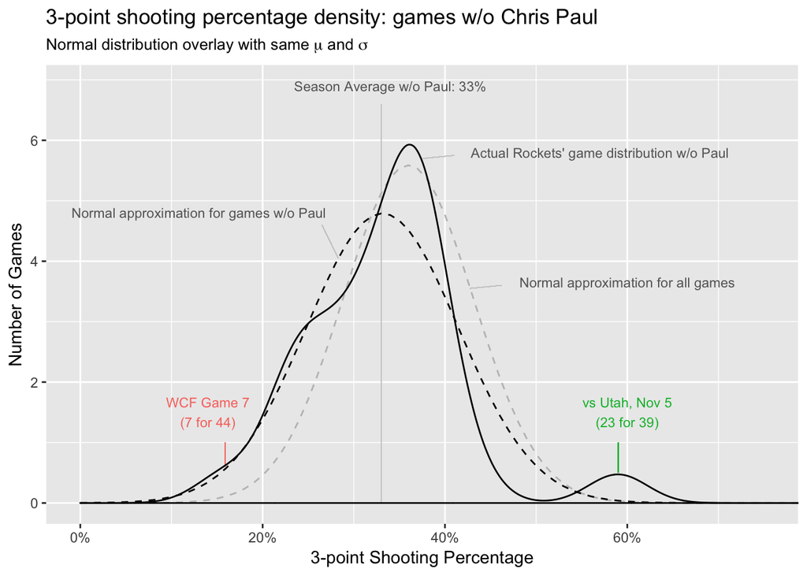

Using the “no-Chris-Paul” distribution, the Utah game becomes about 30% more likely (1 in 867). Odds for a game 7 (or worse) type game, however, goes from 1 in 486 to **1 in 59**. That certainly makes game 7 look a lot less like [dying by car (let alone by dog)](https://www.iii.org/fact-statistic/facts-statistics-mortality-risk) and more like a (really) bad day at the office. [Terrible, Horrible, No Good, Very Bad Day](https://www.amazon.com/Alexander-Terrible-Horrible-Classic-Board/dp/1442498161) it may be, but that’s still a snake-bit game given that Houston didn’t come anywhere close to playing 59 games without Paul.

So perhaps game 7 wasn’t a no-chance-we’ll-ever-see-that-again disaster, but rather, a much more likely hazard of making a living of a lot of relatively low percentage shots. Either way, it was certainly a cruel twist of fate for Houston and Chris Paul that he had to sit out game 7. A game, that had he played, may well have resulted in Houston playing the Cavaliers in the Finals.